# EDRM 718: Assignment #12-Learning Group Project H Report

The following submission is my section of the Learning Group Project H.

## Introduction

A graduate researcher from the University of South Carolina utilized the HSB2 dataset. She acquired the data from the National Center for Educational Statistics which randomly sampled 200 highschool seniors. The sample was divided into two groups by school type (either public or private school). The following report will aim to address the following research questions: *Is there an association of reading and writing scores for each school type?*

## Analysis

The goal of this data analysis is to examine the extent to which there is possible variability in the association of student’s reading and writing scores within public and private school separately.

In the script below, I use the dataset to find the correlations and 95% confidence intervals of the reading-writing associations in each school type.

```r
hsb2 <- read_csv("hsb2.csv")
# Subset private and public school type first
public = subset(hsb2, hsb2$schtyp == "1")
private = subset(hsb2, hsb2$schtyp == "2")
# correlations & 95% confidence intervals of the reading-writing
# associations in each school type
cor.test(public$read, public$write)
```

```
    Pearson's product-moment correlation

data:  public$read and public$write
t = 10.04, df = 166, p-value < 2.2e-16
alternative hypothesis: true correlation is not equal to 0
95 percent confidence interval:
 0.5107937 0.7008500
sample estimates:
      cor
0.6146658
```

```r
cor.test(private$read, private$write)
```

```
    Pearson's product-moment correlation

data:  private$read and private$write
t = 2.535, df = 30, p-value = 0.0167
alternative hypothesis: true correlation is not equal to 0
95 percent confidence interval:
 0.08356682 0.67051297
sample estimates:
      cor
0.4200217
```

Figure 1: Graph illustrating the association of reading and writing scores in public school.

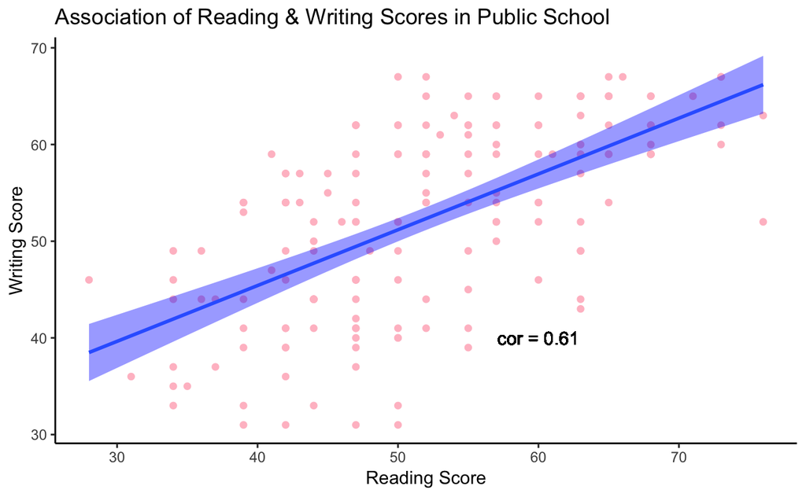

```r
# Reading-Writing Association in Public School
ggplot(data = public, mapping = aes(x = read, y = write)) +
geom_point(color = "pink") +
geom_text(aes(60, 40, label = "cor = 0.61")) +
stat_smooth (method = "lm", fill = "blue") +
theme_classic() +
  labs(x = "Reading Score",
       y = "Writing Score",
      title = "Association of Reading & Writing Scores in Public School")
```

Figure 2: Graph illustrating the association of reading and writing scores in private school.

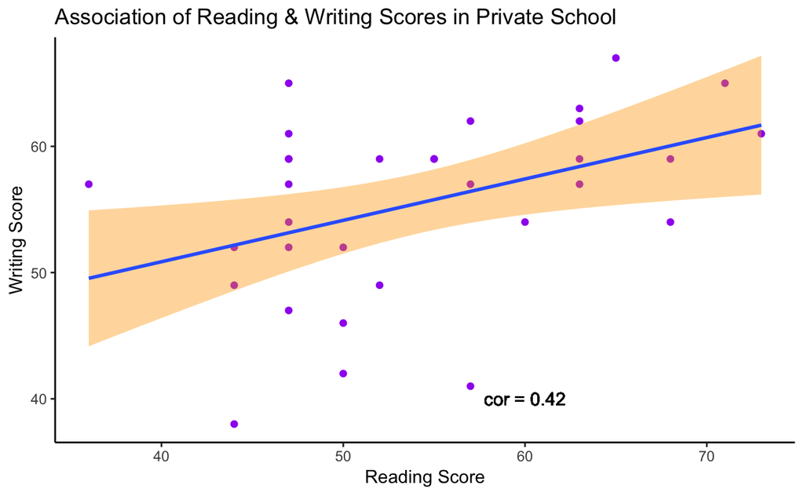

```r
# Reading-Writing Association in Private School
ggplot(data = private, mapping = aes(x = read, y = write)) +
  geom_point(color = "purple") +
  geom_text(aes(60, 40, label = "cor = 0.42")) +
  stat_smooth (method = "lm", fill = "orange") +
  theme_classic() +
  labs(x = "Reading Score",
       y = "Writing Score",
       title = "Association of Reading & Writing Scores in Private School")
```

*Upon visual examination, Figure 1 and 2 illustrate the association of reading and writing scores for both public and private schools. After conducting statistical analyses, the public-school correlation is 0.61 and the private school correlation is 0.42. There are moderate visible differences in associations between the two schools represented by the correlations. In addition, the analyses provided the following two 95% confidence intervals for public and private schools:*

```
                          0.51 < public < 0.70

                          0.08 < private < 0.67
```

## Conclusion

The graduate researcher examined the potential relationship of highschool senior reading and writing scores for public and private school independently. The findings demonstrate a higher correlation of reading and writing scores for public school than private school.